# Homework #3

Grant Ruedy; GrantRuedy

## Tips at Restaurants

In this homework we will use the `tips` data set. This data set is part of the `reshape2` package. You can load the data set by executing the command:

```r
data(tips, package="reshape2")
```

1. How many parties did the waiter serve? Store the number in `numParty` and print.

```r
numParty <- nrow(tips)
numParty
```

```
## [1] 244
```

2. What are the types of variables in the data frame `tips`?

```r
str(tips)
```

```
## 'data.frame':    244 obs. of  7 variables:
##  $ total_bill: num  17 10.3 21 23.7 24.6 ...
##  $ tip       : num  1.01 1.66 3.5 3.31 3.61 4.71 2 3.12 1.96 3.23 ...
##  $ sex       : Factor w/ 2 levels "Female","Male": 1 2 2 2 1 2 2 2 2 2 ...
##  $ smoker    : Factor w/ 2 levels "No","Yes": 1 1 1 1 1 1 1 1 1 1 ...
##  $ day       : Factor w/ 4 levels "Fri","Sat","Sun",..: 3 3 3 3 3 3 3 3 3 3 ...
##  $ time      : Factor w/ 2 levels "Dinner","Lunch": 1 1 1 1 1 1 1 1 1 1 ...
##  $ size      : int  2 3 3 2 4 4 2 4 2 2 ...
```

3. Create a vector named `day` containing the day of visits in `tips`. The factor levels should be ordered from Thursday to Sunday. Also print the variable.

```r
days <- (tips$day)
a <-factor(days, levels(days) [c(4,1:3)])
day <- sort(a, decreasing = FALSE)
day
```

```
##   [1] Thur Thur Thur Thur Thur Thur Thur Thur Thur Thur Thur Thur Thur Thur
##  [15] Thur Thur Thur Thur Thur Thur Thur Thur Thur Thur Thur Thur Thur Thur
##  [29] Thur Thur Thur Thur Thur Thur Thur Thur Thur Thur Thur Thur Thur Thur
##  [43] Thur Thur Thur Thur Thur Thur Thur Thur Thur Thur Thur Thur Thur Thur
##  [57] Thur Thur Thur Thur Thur Thur Fri  Fri  Fri  Fri  Fri  Fri  Fri  Fri
##  [71] Fri  Fri  Fri  Fri  Fri  Fri  Fri  Fri  Fri  Fri  Fri  Sat  Sat  Sat
##  [85] Sat  Sat  Sat  Sat  Sat  Sat  Sat  Sat  Sat  Sat  Sat  Sat  Sat  Sat
##  [99] Sat  Sat  Sat  Sat  Sat  Sat  Sat  Sat  Sat  Sat  Sat  Sat  Sat  Sat
## [113] Sat  Sat  Sat  Sat  Sat  Sat  Sat  Sat  Sat  Sat  Sat  Sat  Sat  Sat
## [127] Sat  Sat  Sat  Sat  Sat  Sat  Sat  Sat  Sat  Sat  Sat  Sat  Sat  Sat
## [141] Sat  Sat  Sat  Sat  Sat  Sat  Sat  Sat  Sat  Sat  Sat  Sat  Sat  Sat
## [155] Sat  Sat  Sat  Sat  Sat  Sat  Sat  Sat  Sat  Sat  Sat  Sat  Sat  Sat
## [169] Sun  Sun  Sun  Sun  Sun  Sun  Sun  Sun  Sun  Sun  Sun  Sun  Sun  Sun
## [183] Sun  Sun  Sun  Sun  Sun  Sun  Sun  Sun  Sun  Sun  Sun  Sun  Sun  Sun
## [197] Sun  Sun  Sun  Sun  Sun  Sun  Sun  Sun  Sun  Sun  Sun  Sun  Sun  Sun
## [211] Sun  Sun  Sun  Sun  Sun  Sun  Sun  Sun  Sun  Sun  Sun  Sun  Sun  Sun
## [225] Sun  Sun  Sun  Sun  Sun  Sun  Sun  Sun  Sun  Sun  Sun  Sun  Sun  Sun
## [239] Sun  Sun  Sun  Sun  Sun  Sun
## Levels: Thur Fri Sat Sun
```

4. Create a data frame named `female5` containing the meal paid by a female payer in a party with size greater than or euqal to 5. Also print the data frame.

```r
female5 <- tips[tips$size >= 5 & tips$sex== 'Female',]
female5
```

```
##     total_bill  tip    sex smoker  day   time size
## 126      29.80 4.20 Female     No Thur  Lunch    6
## 144      27.05 5.00 Female     No Thur  Lunch    6
## 156      29.85 5.14 Female     No  Sun Dinner    5
```

5. How does the tipping amount (`tip`) depend on the overall bill (`total_bill`)? Describe the relationship in words. Describe at least two types of anomalies in the plot. What do they mean? Use the `ggplot2` package to make a chart.

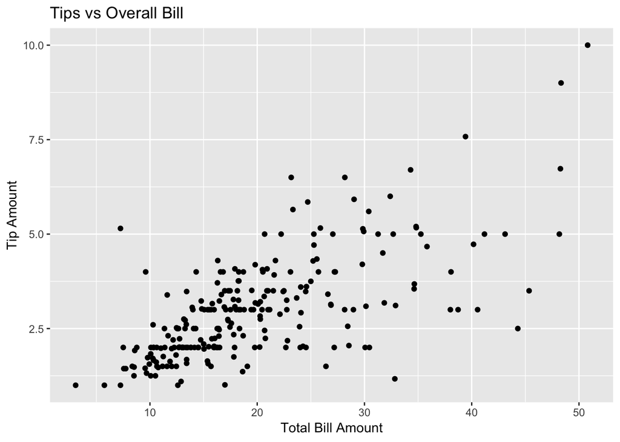

```r
library(ggplot2)
ggplot(tips, aes(x=total_bill, y=tip))  + geom_point() + xlab('Total Bill Amount')+ ylab('Tip Amount') + ggtitle('Tips vs Overall Bill')
```

6. Introduce a variable `tiprate` into the data set, that incorporates the rate of tips. What is the average rate for tips?

```r
tips$tiprate <- tips$tip / tips$total_bill
mean(tips$tiprate)
```

```
## [1] 0.1608026
```

The average rate for tips is 16.08 %

7. Make a boxplot of the tip rate by time. The x-axis should be ordered by lunch and then dinner. Use the `ggplot2` package to make a chart.

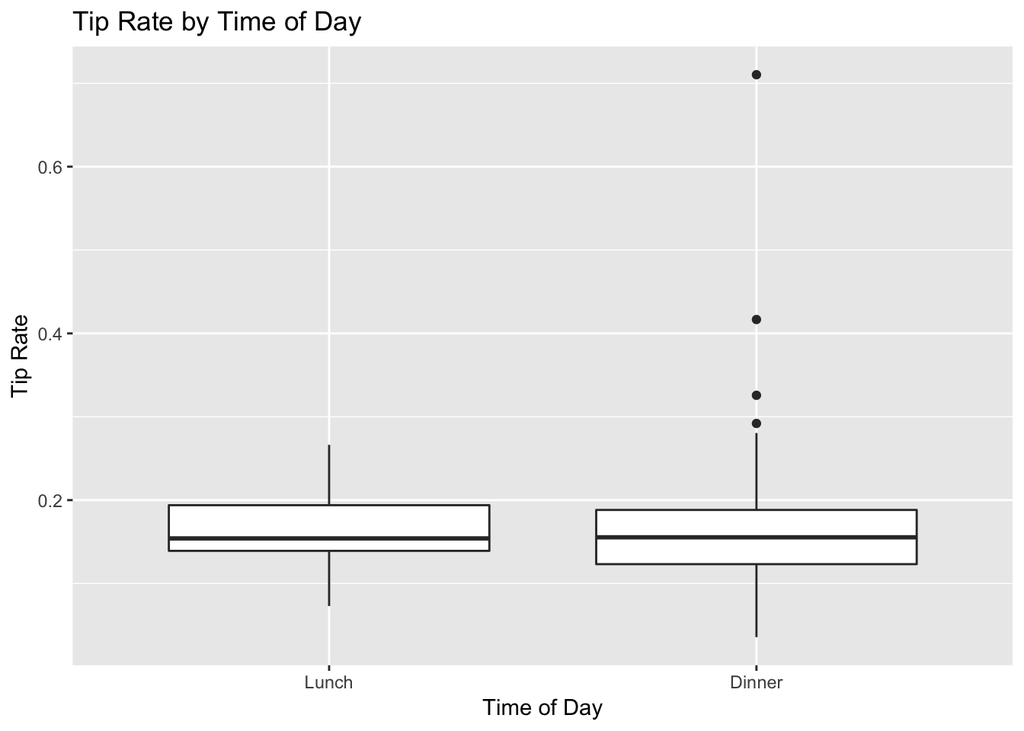

```r
library(ggplot2)

lvl <- levels(tips$time)
time1 <- factor(tips$time, levels=rev(lvl))

ggplot(tips, aes(x=time1, y=tiprate))  + geom_boxplot() + xlab('Time of Day')+ ylab('Tip Rate') + ggtitle('Tip Rate by Time of Day')
```

8. How does smoking behavior and gender of the person who pays impact the relationship between tip and total bill? Find a visualization that incorporates all four variables. Interpret the result.

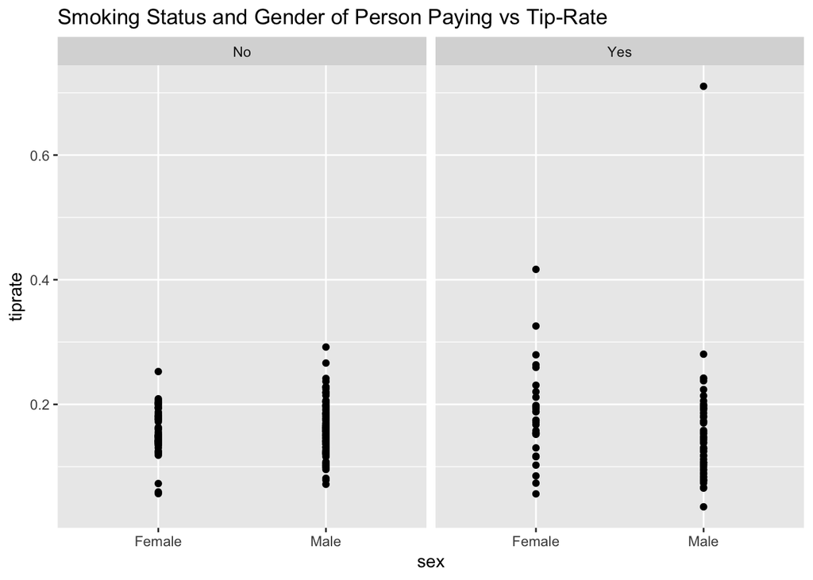

```r
library(ggplot2)
ggplot(tips, aes(x=sex, y=tiprate)) + geom_point() + facet_wrap(~smoker) + ggtitle('Smoking Status and Gender of Person Paying vs Tip-Rate')
```

As shown by the graph, for people who do not smoke, men are on average a little more generous when it comes to the tip. Male non=smokers also vae more variation in how much they tip, as women seem to be more consistent around 15 %. For people who do smoke, men seem to have less variation in their tip rate, and are less generous. There is an outlier where a male smoker tipped over 70 % of the total bill. Women who smoke have more variation in their tip rates, and are more generous compared to men who smoke. however there is not an obvious difference between smokers and non=smokers when it comes to how much they tip in relation to the total bill.

9. Use ggplot2 to find a graphical summary of the relationship between day of the week and gender of the person paying the bill. What can you say about this relationship?

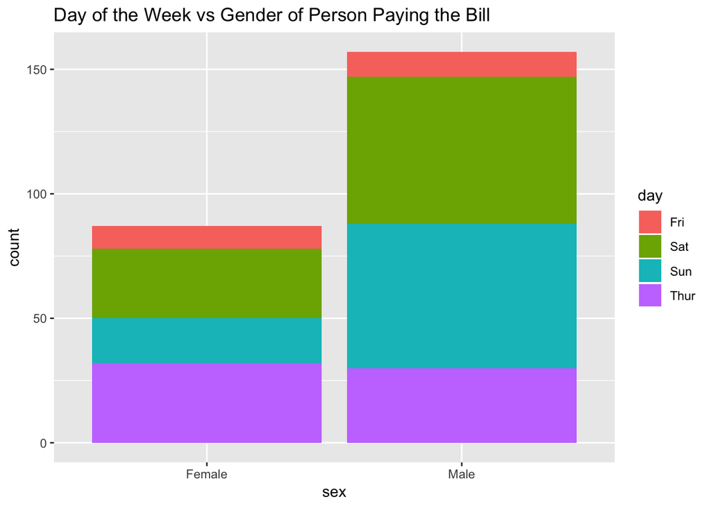

```r
library(ggplot2)
ggplot(tips, aes(x=sex, fill=day))+ geom_bar() + ggtitle('Day of the Week vs Gender of Person Paying the Bill')
```

As shown by the graph, men pay for the bill a lot more on Saturdays and Sundays. Women actually pay for the bill more often on Thursdays. Both genders seem to evenly split the tab on Fridays. Based off of this, since men pay more on the weekend, they might be trying to take their partner out on a date and want to impress them by paying the bill.